# covid 19

Jose Torres Vargas

5/2/2020

### Data is from the Patient_Info dataset from South Korea 1 Jan to 1 May

### This is contained in a downloadable zip file from kaggle

Some of the data was uncoded for sex - sex must be just male or female 77 of the data entries were coded sex as blank, so we omit these. state of a patient must be died or alive - we adjust that as well

# Question 1 - Is dying independent of sex

Table of patients:

```r
# cross tabulation, patient state by gender

with(kRdataOld, table(Sex, result))
```

```
##    result
## Sex alive dead
##   F   716   22
##   M   431   39
```

## We create two bar charts - one based on frequency and the other on percent

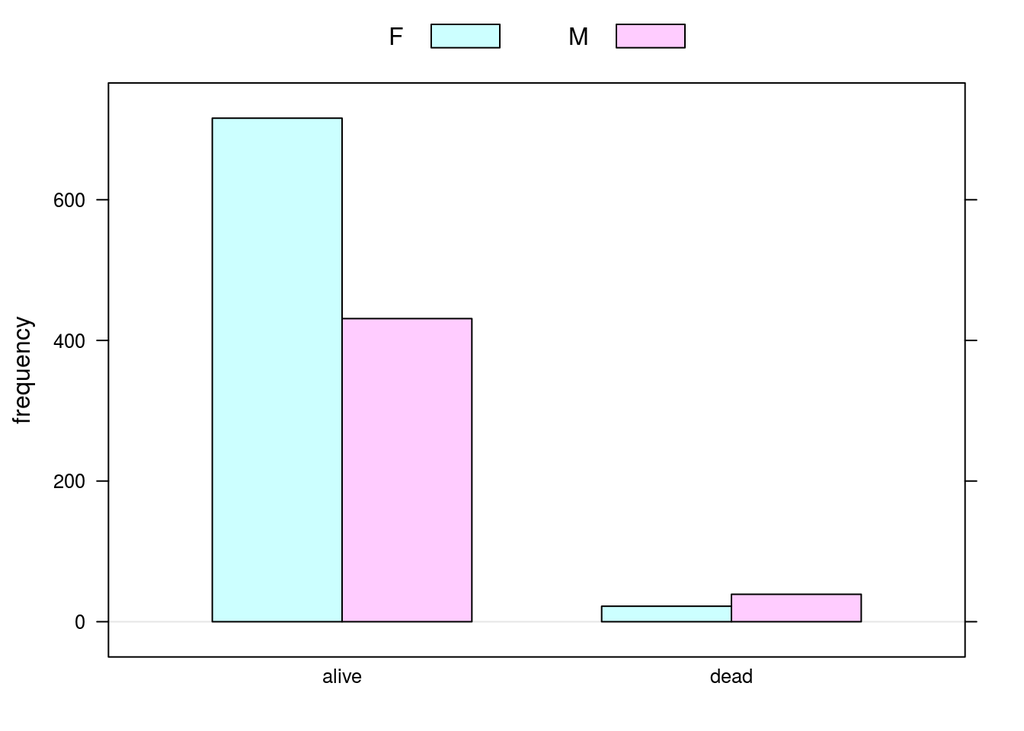

```r
barchartGC(~result + Sex,data=kRdataOld)
```

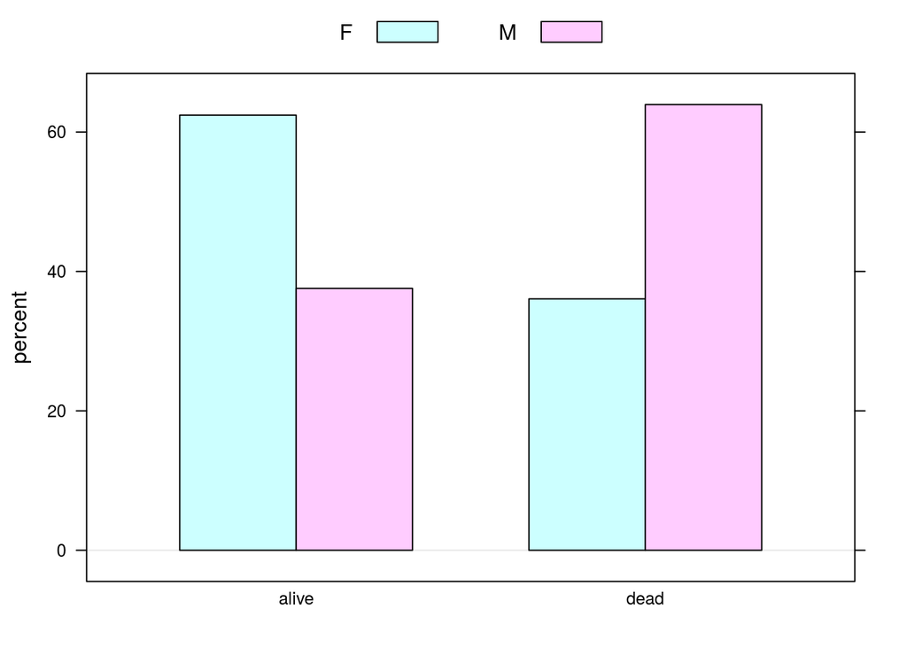

```r
barchartGC(~result + Sex,data=kRdataOld,type="percent")
```

## We see from our row percent numerical data a disparity between men and women

```r
table1 <- xtabs(~result + Sex,data=kRdataOld)
rowPerc(table1)
```

```
##        Sex
## result       F      M  Total
##   alive  62.42  37.58 100.00
##   dead   36.07  63.93 100.00
```

```r
colPerc(table1)
```

```
##        Sex
## result       F     M
##   alive  97.02  91.7
##   dead    2.98   8.3
##   Total 100.00 100.0
```

## Inferential results are significant above the .005 level

```r
chisq.test(table1)
```

```
##
##  Pearson's Chi-squared test with Yates' continuity correction
##
## data:  table1
## X-squared = 15.838, df = 1, p-value = 6.899e-05
```

```r
chisqtestGC(table1)
```

```
## Pearson's Chi-squared test with Yates' continuity correction
##
## Observed Counts:
##        Sex
## result    F   M
##   alive 716 431
##   dead   22  39
##
## Counts Expected by Null:
##        Sex
## result       F      M
##   alive 700.73 446.27
##   dead   37.27  23.73
##
## Contributions to the chi-square statistic:
##        Sex
## result     F    M
##   alive 0.33 0.52
##   dead  6.25 9.82
##
##
## Chi-Square Statistic = 15.8384
## Degrees of Freedom of the table = 1
## P-Value = 1e-04
```

```r
fisher.test(table1)
```

```
##
##  Fisher's Exact Test for Count Data
##
## data:  table1
## p-value = 6.786e-05
## alternative hypothesis: true odds ratio is not equal to 1
## 95 percent confidence interval:
##  1.676061 5.285176
## sample estimates:
## odds ratio
##   2.942211
```

# Question 2 what is the age distribution of those who contracted Covid contrasted with those who died

Since we have the birth year, we wii simply plot the difference between that and 2020 we will form two plots one for everyone ane one for just those who died

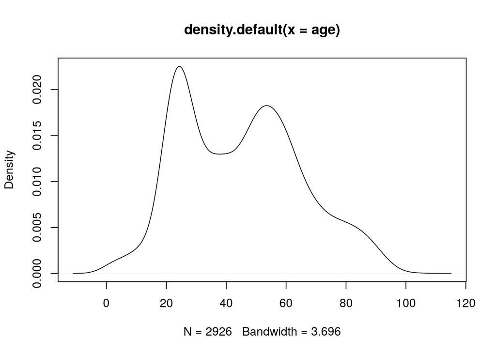

```r
age = 2020-na.omit(kRdata$birth_year)
plot(density(age))
```

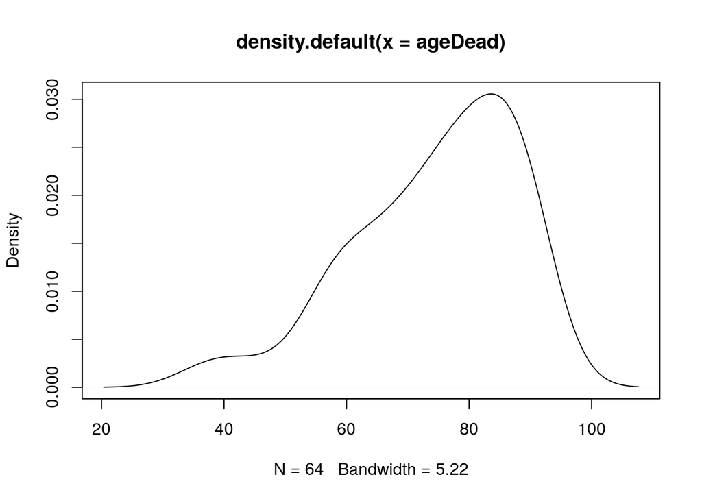

```r
kDead <- filter(kRdata,result=="dead")
ageDead =2020-na.omit(kDead$birth_year)
plot(density(ageDead))
```

# Question 3 When did the people get covid

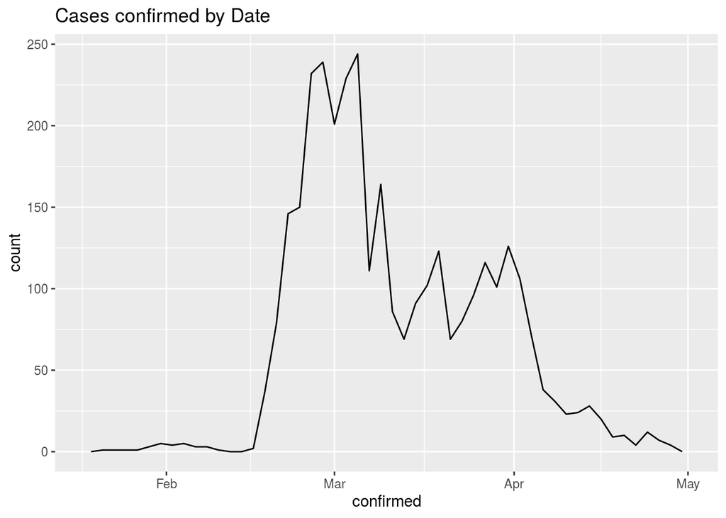

```r
# create date with lubridate
kRdata$confirmed <- ymd(kRdata$confirmed_date)
ggplot(kRdata,aes(confirmed)) +
geom_freqpoly(binwidth=2,na.rm=TRUE) +
ggtitle("Cases confirmed by Date")
```

# Question 4 Time it goes on

```r
kRdata$kRdataRelease <- ymd(kRdata$released_date)
kRdata$kRdataDead <- ymd(kRdata$deceased_date)
```

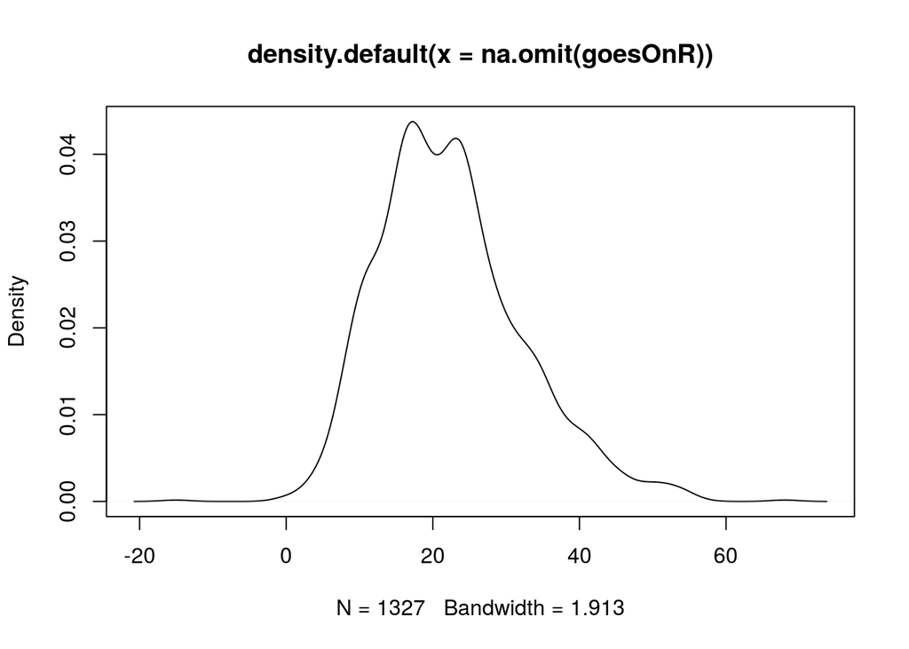

```r
goesOnR <-  as.numeric(kRdata$kRdataRelease) - as.numeric(kRdata$confirmed)
plot(density(na.omit(goesOnR)))
```

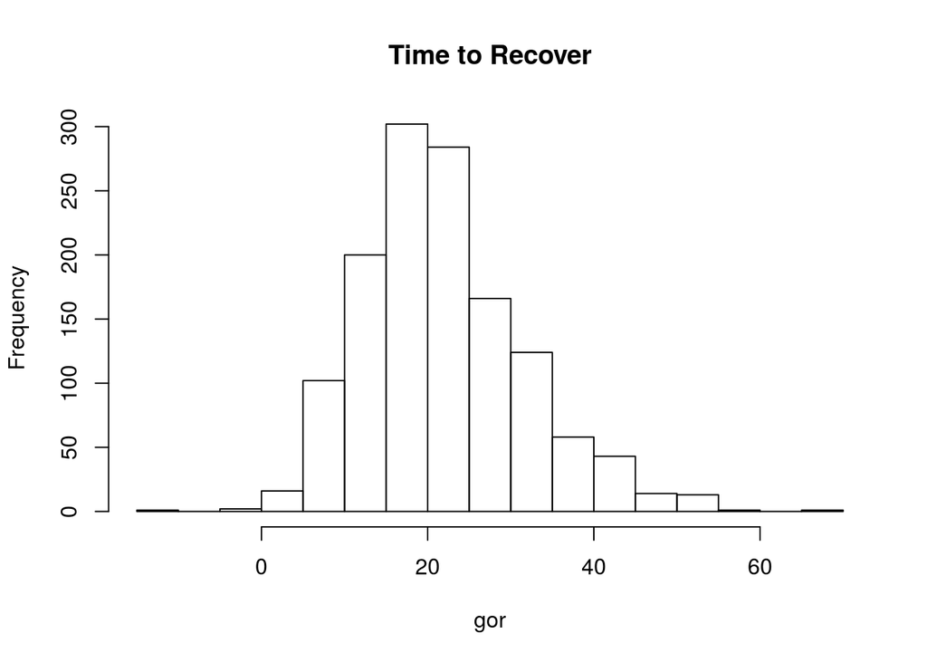

```r
gor <- na.omit(goesOnR)
hist(gor,main=paste("Time to Recover"))
```

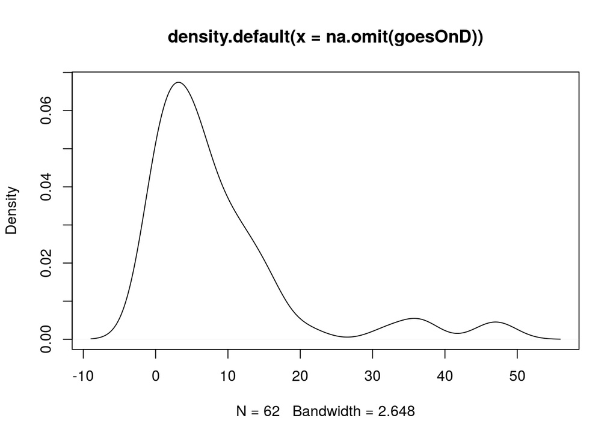

```r
goesOnD <-  as.numeric(kRdata$kRdataDead) - as.numeric(kRdata$confirmed)
plot(density(na.omit(goesOnD)))
```

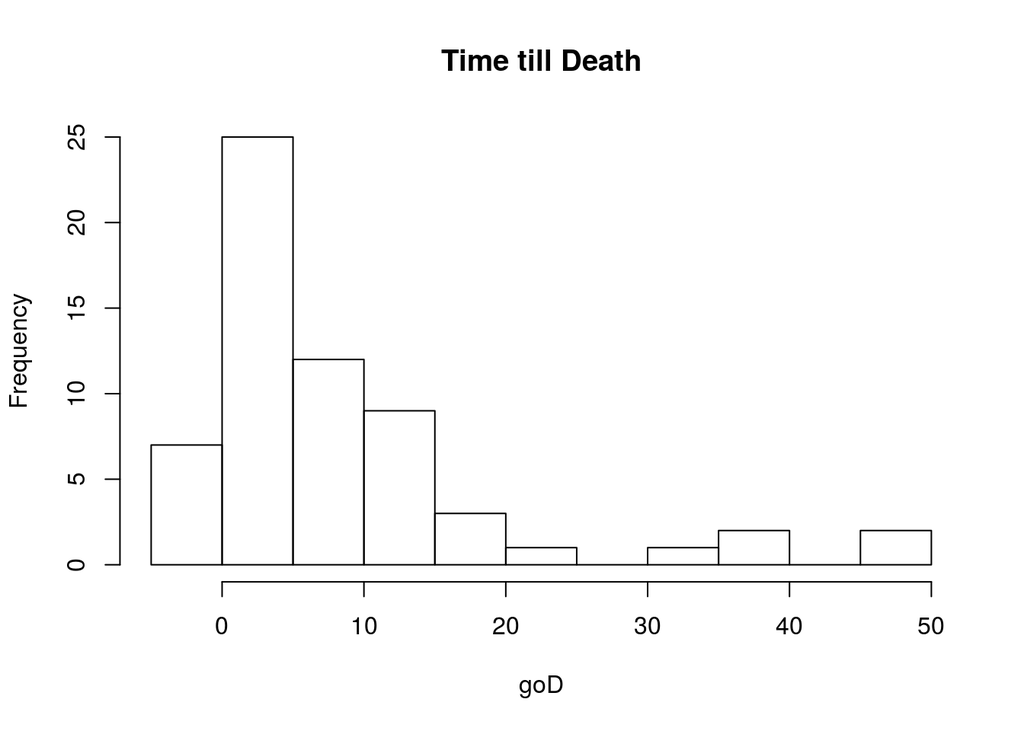

```r
goD <-na.omit(goesOnD)
hist(goD,main=paste("Time till Death"))
```

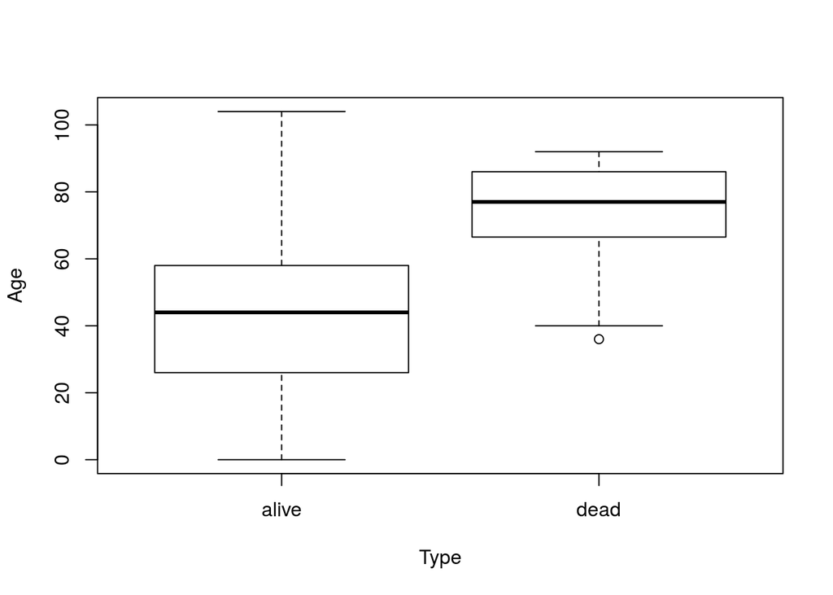

```r
boxplot(kRdata$age ~ kRdata$result, ylab = "Age", xlab = "Type")
```

```r
jTdata<- filter(kRdata,age !="NA") %>%
  select(result, age) %>%
  mutate(
    type = case_when(
      age < 40 ~ "0 - 39",
      age >= 40 ~ "Older than 40",
      TRUE ~ "other"
    )
  )
table2 <- xtabs(~result + type,data=jTdata)
rowPerc(table2)
```

```
##        type
## result  0 - 39 Older than 40  Total
##   alive  44.16         55.84 100.00
##   dead    1.56         98.44 100.00
```

```r
colPerc(table2)
```

```
##        type
## result  0 - 39 Older than 40
##   alive  99.92         96.21
##   dead    0.08          3.79
##   Total 100.00        100.00
```

```r
fisher.test(table2)
```

```
##
##  Fisher's Exact Test for Count Data
##
## data:  table2
## p-value = 6.604e-15
## alternative hypothesis: true odds ratio is not equal to 1
## 95 percent confidence interval:
##     8.593176 1981.546886
## sample estimates:
## odds ratio
##   49.80241
```

#### see https://data.library.virginia.edu/working-with-dates-and-time-in-r-using-the-lubridate-package/